# tabs

- Rendimiento de Alumnos por Evaluación
- Rendimiento General de los Alumnos
- Rendimiento de Alumnos por Evaluación
- Rendimiento de Alumnos por Evaluación

### Esta es una gráfica de líneas paralelas que muestra el rendimiento de los alumnos en distintas evaluaciones.

### Cada línea representa el desempeño de un estudiante a lo largo de varios temas, y los colores indican el nivel de calificación:

## 🟩 Bueno — desempeño alto

## 🟧 Regular — desempeño medio

## 🟥 Malo — desempeño bajo

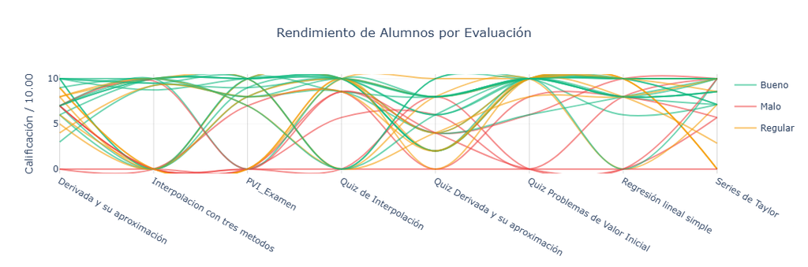

### Esta es una **gráfica de barras horizontales** que muestra el **rendimiento individual de los alumnos**.

### Cada barra representa el promedio o desempeño de un estudiante, ordenado de mayor a menor.

### - Las **barras verdes** indican un rendimiento **bueno**, con calificaciones altas y consistentes.

### - Las **barras naranjas** representan un rendimiento **regular**, con resultados más bajos en comparación con el grupo superior.

### El gráfico permite identificar fácilmente a los alumnos con mejor desempeño y aquellos que podrían requerir apoyo adicional para mejorar sus resultados.

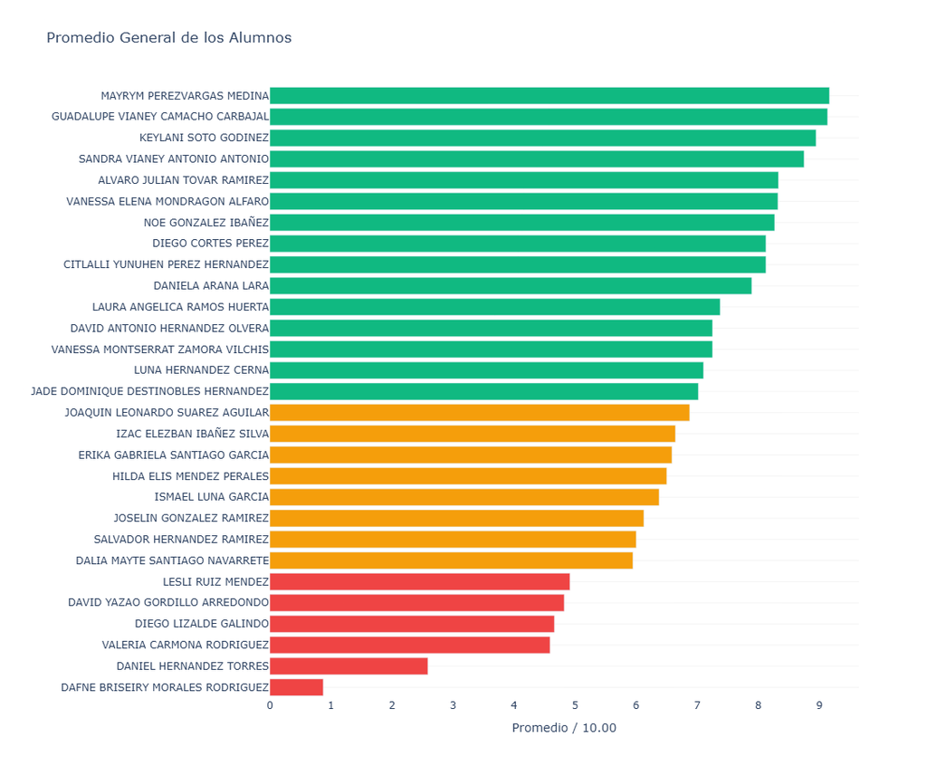